# Lab8

Anna Matarazzo

10/22/2020

## Problem 1

1. Write a function to convert a vector of raw-scores into z-scores. The function should have inputs for the vector, the mean and sd of the normal distribution, and should return a vector of z-scores. (1 point). Also, demonstrate that the function works correctly (1 point). How you make the demonstration is up to you.
- Advanced: Have an option so that the function will convert the raw scores to z-scores in one of two ways:
- using user provided mean and standard deviation
- using the calculated mean and standard deviation from the raw scores

## Key version

```r
to_zscores <- function(raw, mu, sd){
  zscores <- (raw-mu)/sd
  return(zscores)
}

some_numbers <- c(1,2,3,4,5)

to_zscores(some_numbers, 5, 1)
```

```
## [1] -4 -3 -2 -1  0
```

```r
to_zscores_b <- function(raw, mu=NULL, sdev=NULL){
  if(is.null(mu) == TRUE) mu <- mean(raw)
  if(is.null(sdev) == TRUE) sdev <- sd(raw)
  zscores <- (raw - mu)/sdev
  return(zscores)
}

to_zscores_b(some_numbers, 5, 1)
```

```
## [1] -4 -3 -2 -1  0
```

## My version

I didn’t figure out the way to solve the problem before I looked at the key video, so I decided to create a function that will transform your height to z-scores and show you how far away in standard deviations is your height comparing to USA average.

I encountered several problems:

1. I was not able to code a gender in words instead of numbers (i.e. so that the user could write “to_zscores(176, female)”);
2. I was not able to include the graph inside the function (i.e. the user just types “to_zscores(176, female)” in a console and gets the answer and a graph without the need to run the code itself? Is it possible?)

```r
# Enter height in cm and gender (1 - male, 2 - female)

height <- 176
gender <- 2

to_zscores <- function(height, gender){
  if ((gender) == 1)
     zscores <- (height-178)/8
  if ((gender) == 2)
     zscores <- (height-164)/6.35
  return(zscores)
}

your_zscore <- to_zscores(height, gender)
sd <- if (gender == 1) sd <- 8
      if (gender == 2) sd <- 6.4
mu <- if (gender == 1) mu <- 178
      if (gender == 2) mu <- 164
name <- if (gender == 1) name <- c("Height in cm, male")
        if (gender == 2) name <- c("Height in cm, female")

data.frame(your_zscore,
           gender,
           sd,
           mu,
           name)
```

```
##   your_zscore gender  sd  mu                 name
## 1    1.889764      2 6.4 164 Height in cm, female
```

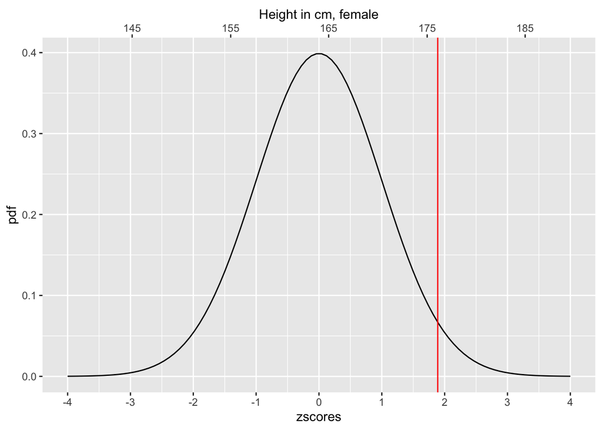

```r
pdf <- dnorm(seq(-4,4,length.out=100),0,1)
zscores <- seq(-4,4,length.out=100)
plot_df <- data.frame(pdf,
                      zscores,
                      your_zscore)

library(dplyr)
library(ggplot2)

ggplot(plot_df,aes(x=zscores,y=pdf))+
  geom_line()+
  geom_vline(xintercept = your_zscore,
             color = "red")+
  scale_x_continuous(breaks=c(-4:4),
  sec.axis = sec_axis(~ .*sd+mu, name = name, breaks=seq(145,215,10)))
```

`Confidence level - 90.`

## Problem 2

2. Base R does not have a function for a z-test. Write a function to accomplish a one-sample z-test. Remember, a one-sample z test is used to compare the probability of obtaining the sample mean (or larger or smaller) if it came from a known normal distribution. (2 points).
- Use your z-test function to conduct a test of the following. A sample of 25 scores is taken. The mean of the sample is 50. The sample is assumed to have been taken from a normal distribution with mean 40 and standard deviation 7. Report a one-tailed z-test, examining the probability of obtaining a sample of greater than 50 in this situation. Report the results, and give a brief sentence explaining the result and the inference you make (2 points).

```r
z.test <- function(sample_mean,
                   sample_size,
                   mu,
                   sigma,
                   two.tailed=TRUE){

  sampl_dist_mean <- mu
  sampl_dist_sd <- sigma/sqrt(sample_size)

  abs_difference <- abs(sample_mean - mu)

  p_value <- pnorm((mu+abs_difference), sampl_dist_mean, sampl_dist_sd, lower.tail = FALSE)
  if(two.tailed == TRUE) p_value <- p_value*2
  p_value

}

z.test(37, 5, 40, 7, two.tailed = FALSE)
```

```
## [1] 0.168952
```

`Confidence level - 60.`